# Ejercicio 8

Ricardo Lastra

15 de Noviembre de 2017

Participación de mercado, promoción y precios (Congdon, 2001). Se tiene una serie de tiempo semanal de la participación de mercado (St) de un producto de consumo, durante un período de dos años (1990- 1991). El número total de observaciones es N104. Las fluctuaciones en la participación de mercado están relacionadas con (Pt) precio del producto relativo al promedio para esos productos, (OPROMt) índice del nivel de promoción del producto y (CPROMt) índice de productos competidores. El impacto en la participación de mercado debido a un aumento del precio y a un aumento de la promoción de la competencia debería de ser negativo, mientras que un aumento en la promoción del propio producto debería aumentar la participación del mercado. Se sugieren dos modelos para estos datos:

1. Modelo Estático:

$$S_t =\beta_{0}+\beta_1P_t+\beta_2OPROM_t+\beta_3CPROM_t+\epsilon_{t},\epsilon_{t} \thicksim N(0,\tau)\\$$

Las distribuciones iniciales sugeridas por Congdon (2001) son:

$$\beta_0 \thicksim N(42,0.04),\ \beta_1 \thicksim N(0,0.25),\ \beta_2 \thicksim N(0,0.25),\ \beta_3 \thicksim N(0,0.25)\\$$

2. Modelo Dinámico

$$S_t =\beta_{0t}+\beta_{1t}P_t+\beta_{2t}OPROM_t+\beta_{3t}CPROM_t+\epsilon_{t},\epsilon_{t} \thicksim N(0,V_t^{-1})\\
\beta_{jt}=\beta_{jt-1}+\omega_{jt},\omega_{jt} \thicksim N(0,W_{jt}^{-1}),\ j=0,1,2,3\\
V_{t}^{-1}=\delta^{t-1}V^{-1},\ t=1,2...\\
W_{jt}^{-1}=(\delta_j)^{t-1}W_j^{-1},\ j=0,..,3\ y\ t=1,2,...$$

donde $\delta$ y $\delta_j$ son factores de descuento de las varianzas observacional y de la evolucion de los parametros, respectivamente.

Los valores de descuento sugeridos son:

$$\delta=0.99,\ \delta_0=0.99,\ \delta_1=1,\ \delta_2=1,\ \delta_3=1.$$
Las distribuciones iniciales son:

$$\beta_{00} \thicksim N(42,0.04),\ \beta_{10} \thicksim N(0,0.25)I(\beta_{10}<0),\ \beta_{20} \thicksim N(0,0.25)I(\beta_{20}>0),\ \beta_{03} \thicksim N(0,0.25)I(\beta_{30}<0),\\ V^{-1} \thicksim Ga(0.5,0.5)\ y\ W_j^{-1} \thicksim Ga(1,1),j=0,...,3.\\$$

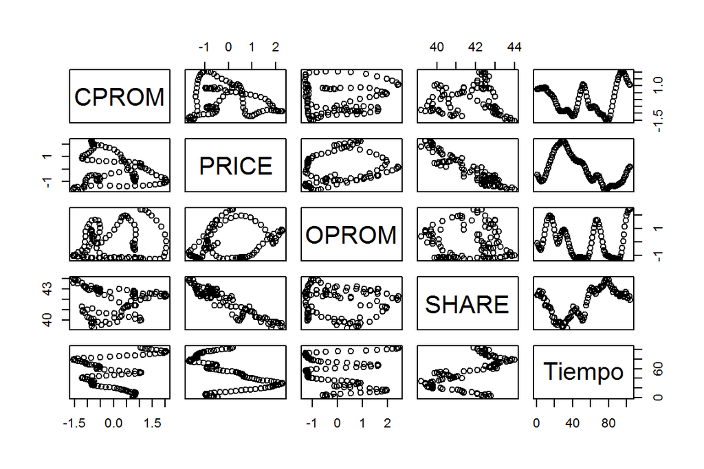

```r
#By Ricardo Lastra
#install.packages("R2jags")
library(R2jags)

wdir<-getwd()
setwd(wdir)

#-------Funciones utiles----------
prob <- function(x){
  out <- min(length(x[x>0])/length(x),length(x[x<0])/length(x))
  out
}
mercado<-read.table("http://allman.rhon.itam.mx/~lnieto/index_archivos/mercado.txt",header=TRUE)
n<-nrow(mercado)
mercado$Tiempo<-1:n
pairs(mercado)
```

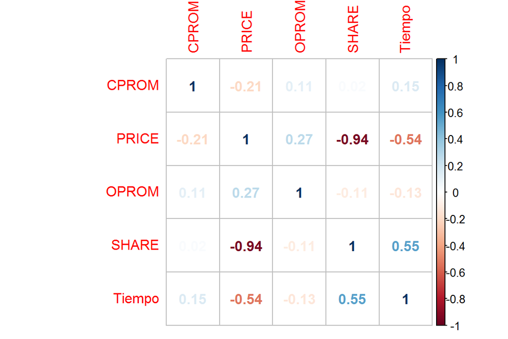

```r
data<-list("n"=n,"y"=scale(mercado$SHARE)[1:n],"x1"=scale(mercado$PRICE)[1:n],"x2"=scale(mercado$OPROM)[1:n],"x3"=scale(mercado$CPROM)[1:n])
corre<-cor(mercado)
#Grafica de correlación mas visual
library(corrplot)
corrplot(corre, method = "number")
```

### Ejercicio C)

Obtener el DIC con el modelo de ordenada estatica con pendientes dinamicas.

Modelo:

```r
#Inits
inits<-function(){list(alpha=0,beta=matrix(0,nrow=3,ncol=n),tau=1,yf1=rep(1,n))} #ejercico c
#-Selecting parameters to monitor
parameters<-c("alpha","beta","tau","yf1")
#-Running code
ej8c.sim<-jags(data,inits,parameters,model.file="Ej8c.txt",
               n.iter=10000,n.chains=1,n.burnin=1000,n.thin=10)
#Usando:

#model
#{
#Likelihood  C
#for (i in 1:n) {
#   y[i] ~ dnorm(mu[i],tau)
#   mu[i]<-alpha+beta[1,i]*x1[i]+beta[2,i]*x2[i]+beta[3,i]*x3[i]
#   }
#State eq.
#for (i in 2:n) {
#for (j in 1:3) {
#   beta[j,i] ~ dnorm(beta[j,i-1],tau.b[j])
#   }
#   }
#Priors
#alpha ~ dnorm(0,0.001)
#for (j in 1:3) { beta[j,1] ~ dnorm(0,0.001) }
#tau ~ dgamma(0.001,0.001)
#for (j in 1:3){
#   tau.b[j]<- lam*tau
#}
#lam<-10

#Prediction 1
#for (i in 1:n) { yf1[i] ~ dnorm(mu[i],tau) }

#}
```

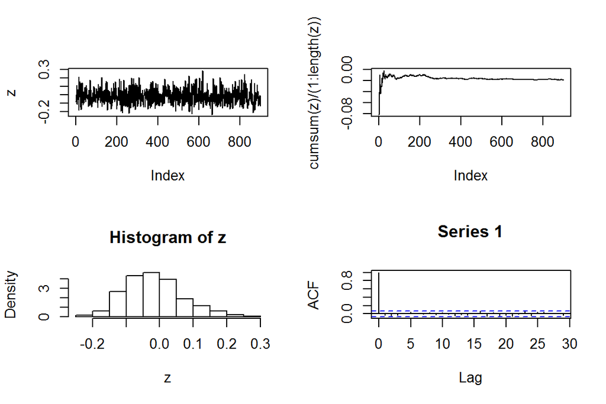

```r
out<-ej8c.sim$BUGSoutput$sims.list

z<-out$alpha
par(mfrow=c(2,2))
plot(z,type="l")
plot(cumsum(z)/(1:length(z)),type="l")
hist(z,freq=FALSE)
acf(z)
```

```r
#Resumen de estimadores
out.sum<-ej8c.sim$BUGSoutput$summary

#Tabla resumen
out.sum.t<-out.sum[grep("beta",rownames(out.sum)),c(1,3,7)]
out.sum.t<-cbind(out.sum.t,apply(out$beta,2,prob))
dimnames(out.sum.t)[[2]][4]<-"prob"
#print(out.sum.t)  Comentamos para evitar impresion de las 100 betas
```

```r
#DIC
out.dic<-ej8c.sim$BUGSoutput$DIC
print(out.dic)
```

```
## [1] 77.44331
```

Predicciones:

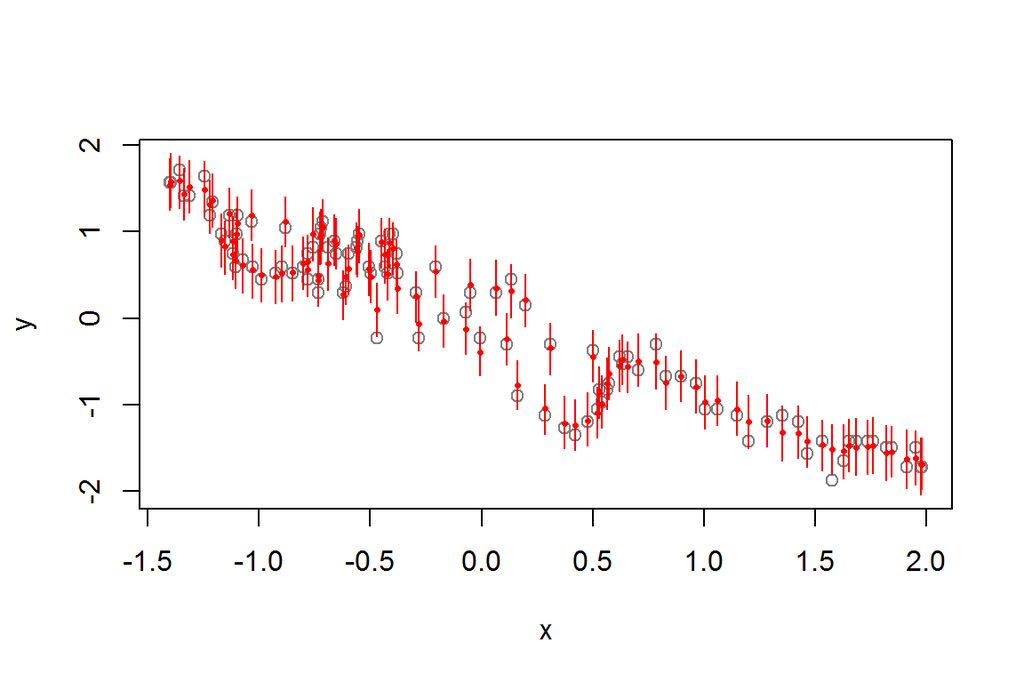

```r
out.yf<-out.sum[grep("yf1",rownames(out.sum)),]
y<-data$y
ymin<-min(y,out.yf[,c(1,3,7)])
ymax<-max(y,out.yf[,c(1,3,7)])

#x1 vs. y
x<-data$x1
par(mfrow=c(1,1))
plot(x,y,type="p",col="grey50",ylim=c(ymin,ymax))
points(x,out.yf[,1],col=2,pch=16,cex=0.5)
segments(x,out.yf[,3],x,out.yf[,7],col=2)
```

Medias:

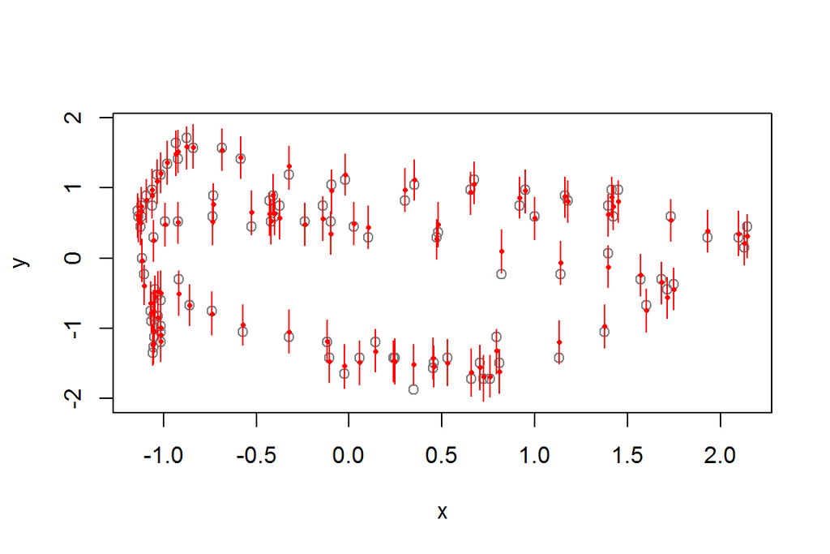

```r
#x2 vs. y
x<-data$x2
par(mfrow=c(1,1))
plot(x,y,type="p",col="grey50",ylim=c(ymin,ymax))
points(x,out.yf[,1],col=2,pch=16,cex=0.5)
segments(x,out.yf[,3],x,out.yf[,7],col=2)
```

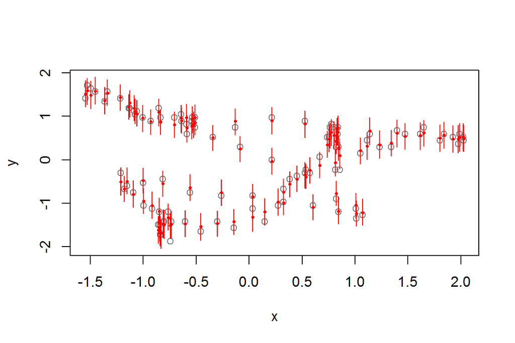

```r
#x3 vs. y
x<-data$x3
par(mfrow=c(1,1))
plot(x,y,type="p",col="grey50",ylim=c(ymin,ymax))
points(x,out.yf[,1],col=2,pch=16,cex=0.5)
segments(x,out.yf[,3],x,out.yf[,7],col=2)
```

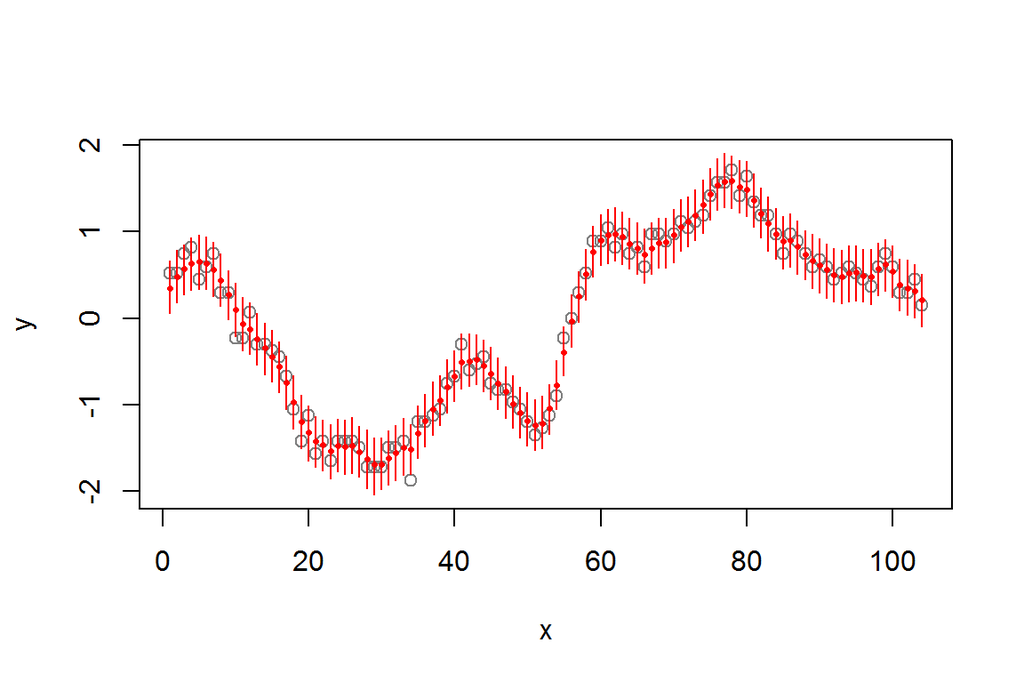

```r
#t vs. y
x<-mercado$Tiempo
par(mfrow=c(1,1))
plot(x,y,type="p",col="grey50",ylim=c(ymin,ymax))
points(x,out.yf[,1],col=2,pch=16,cex=0.5)
segments(x,out.yf[,3],x,out.yf[,7],col=2)
```

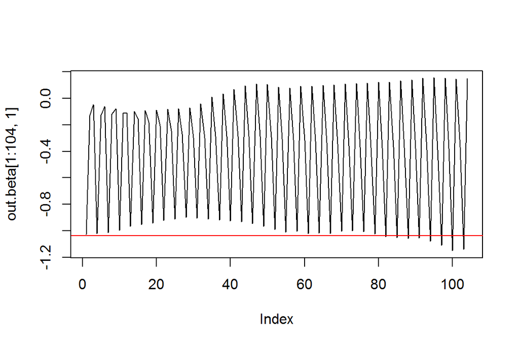

```r
#betas
out.beta<-out.sum[grep("beta",rownames(out.sum)),]
plot(out.beta[1:104,1],type="l")
abline(h=-1.0376912, col=2)
```

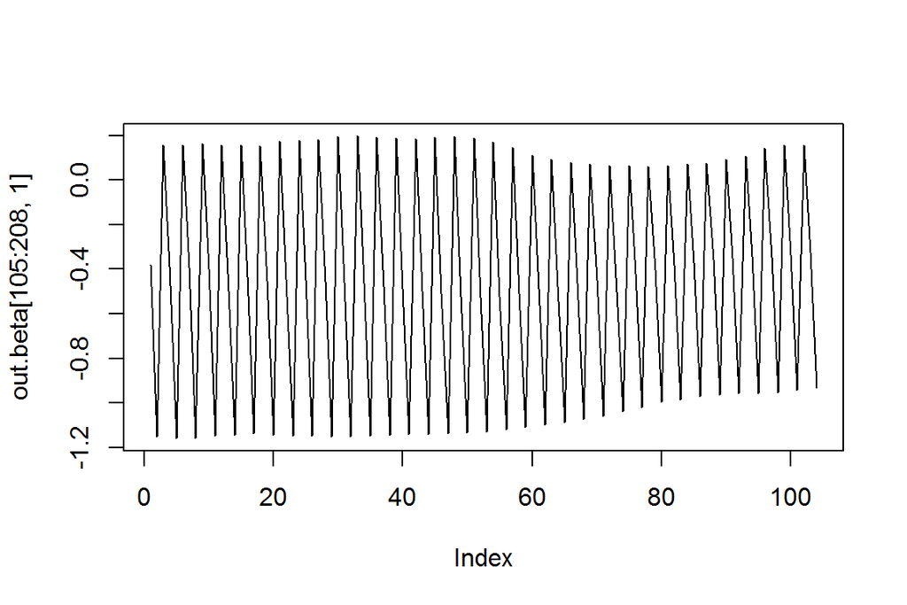

```r
plot(out.beta[105:208,1],type="l")
```

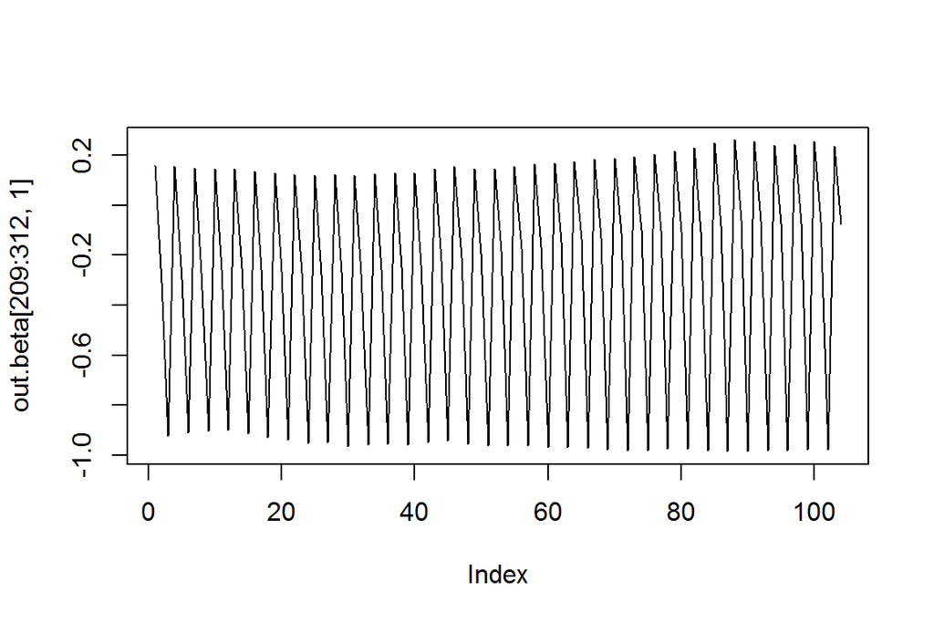

```r
plot(out.beta[209:312,1],type="l")
```

### Ejercicio D) Usando ordenada dinamica con pendientes estaticas.

```r
#Inits
inits<-function(){list(alpha=rep(0,n),beta=rep(0,3),tau=1,yf1=rep(1,n))} #ejercico d
#ejercico d
#-Running code
ej8d.sim<-jags(data,inits,parameters,model.file="Ej8d.txt",
               n.iter=10000,n.chains=1,n.burnin=1000,n.thin=1)
```

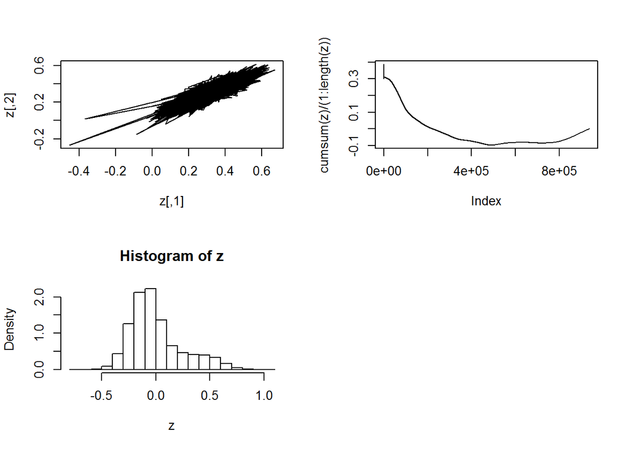

```r
out<-ej8d.sim$BUGSoutput$sims.list
z<-out$alpha
par(mfrow=c(2,2))
plot(z,type="l")
plot(cumsum(z)/(1:length(z)),type="l")
hist(z,freq=FALSE)
#acf(z)
```

```r
#Resumen de estimadores
out.sum<-ej8d.sim$BUGSoutput$summary
#Tabla resumen
out.sum.t<-out.sum[grep("beta",rownames(out.sum)),c(1,3,7)]
out.sum.t<-cbind(out.sum.t,apply(out$beta,2,prob))
dimnames(out.sum.t)[[2]][4]<-"prob"
#print(out.sum.t)  Comentamos para evitar impresion de las 100 betas
```

```r
#DIC
out.dic<-ej8d.sim$BUGSoutput$DIC
```

### El DIC del modelo con ordenada dinamica y con pendientes estaticas es:

```r
#DIC
print(out.dic)
```

```
## [1] -43.96734
```

Predicciones:

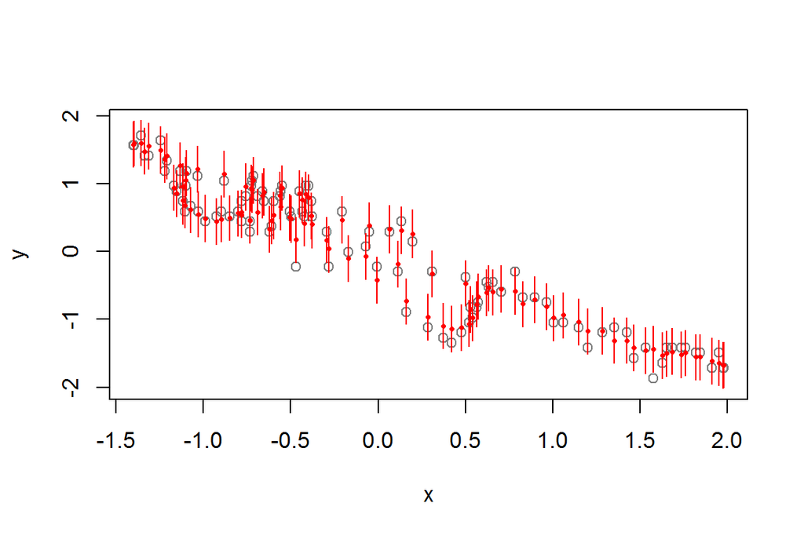

```r
out.yf<-out.sum[grep("yf1",rownames(out.sum)),]
y<-data$y
ymin<-min(y,out.yf[,c(1,3,7)])
ymax<-max(y,out.yf[,c(1,3,7)])

#x1 vs. y
x<-data$x1
par(mfrow=c(1,1))
plot(x,y,type="p",col="grey50",ylim=c(ymin,ymax))
points(x,out.yf[,1],col=2,pch=16,cex=0.5)
segments(x,out.yf[,3],x,out.yf[,7],col=2)
```

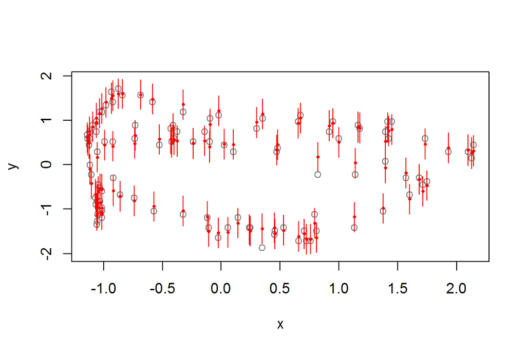

```r
#x2 vs. y
x<-data$x2
par(mfrow=c(1,1))
plot(x,y,type="p",col="grey50",ylim=c(ymin,ymax))
points(x,out.yf[,1],col=2,pch=16,cex=0.5)
segments(x,out.yf[,3],x,out.yf[,7],col=2)
```

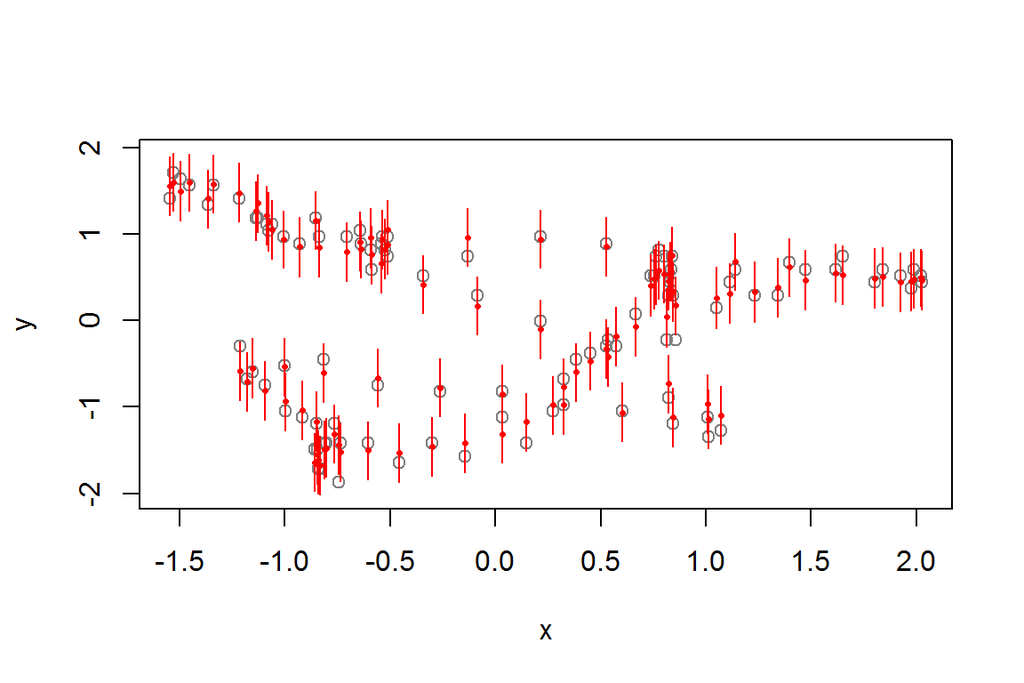

```r
#x3 vs. y
x<-data$x3
par(mfrow=c(1,1))
plot(x,y,type="p",col="grey50",ylim=c(ymin,ymax))
points(x,out.yf[,1],col=2,pch=16,cex=0.5)
segments(x,out.yf[,3],x,out.yf[,7],col=2)
```

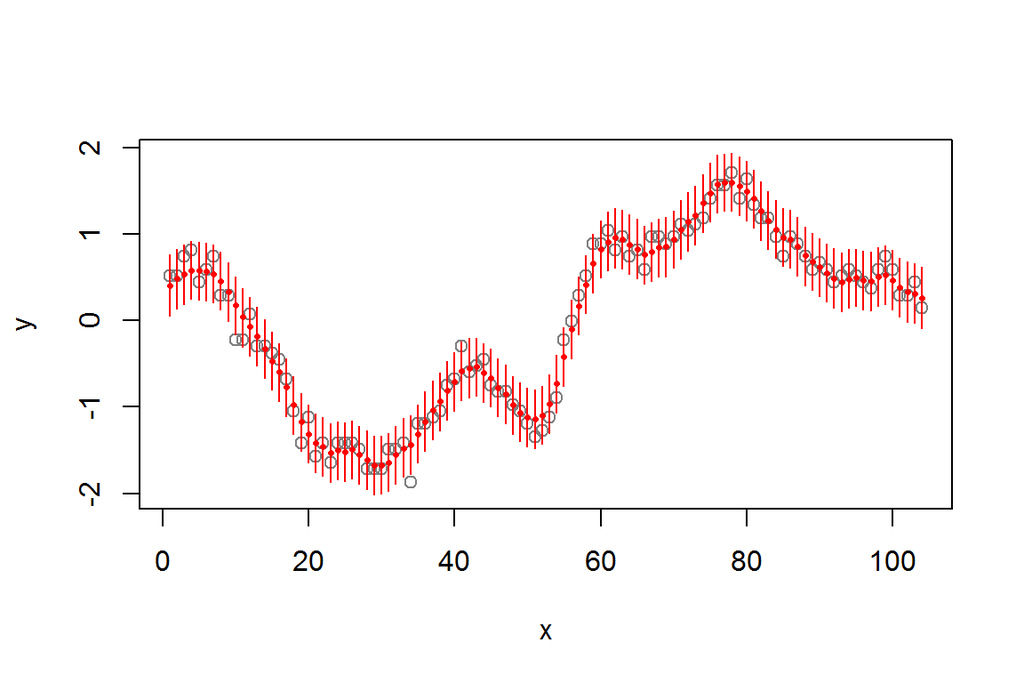

```r
#t vs. y
x<-mercado$Tiempo
par(mfrow=c(1,1))
plot(x,y,type="p",col="grey50",ylim=c(ymin,ymax))
points(x,out.yf[,1],col=2,pch=16,cex=0.5)
segments(x,out.yf[,3],x,out.yf[,7],col=2)
```

### Conclusiones:

Observamos que al cambiar el modelo con la ordenada dinamica y pendientes estaticas, se ajusta mejor a las salidas del modelo respecto a los resultados del modelo c). La `beta` en el modelo estatico nos dice el cambio en el valor esperado de la repsuesta. El impatco depende de las unidades de medida.